# Reproducible Research: Peer Assessment 1

## Read the file

```r
setwd("C:/Vasu/R_Coursera/ReproducibleResearch/repdata-data-activity")
list.files()
```

```
## [1] "activity.csv"
```

```r
data <- read.csv("activity.csv")
head(data)
```

```
##   steps       date interval
## 1    NA 2012-10-01        0
## 2    NA 2012-10-01        5
## 3    NA 2012-10-01       10
## 4    NA 2012-10-01       15
## 5    NA 2012-10-01       20
## 6    NA 2012-10-01       25
```

### Data has three variables.

#### steps: Number of steps taking in a 5-minute interval (missing values are coded as NA)

#### date: The date on which the measurement was taken in YYYY-MM-DD format

#### interval: Identifier for the 5-minute interval in which measurement was taken

## What is mean total number of steps taken per day?

```r
library(ggplot2)
total.steps <- tapply(data$steps, data$date, FUN = sum, na.rm = TRUE)
#total.steps
```

## Histogram for total number of steps taken each day.

### Calculate and report the mean and median total number of steps taken per day

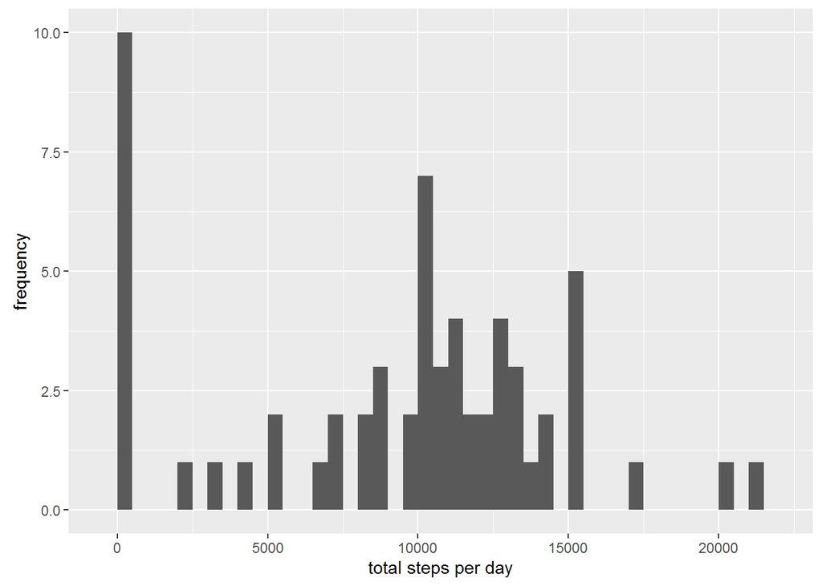

```r
qplot(total.steps, binwidth = 500, xlab = "total steps per day", ylab = "frequency")
```

```r
mean(total.steps, na.rm = TRUE)
```

```
## [1] 9354.23
```

```r
# 9354.23
median(total.steps, na.rm = TRUE)
```

```
## [1] 10395
```

```r
# 10395
```

## What is the average daily activity pattern?

```r
daily.average <- aggregate(x = list(steps = data$steps), by = list(interval = data$interval),FUN = mean, na.rm = TRUE)
#daily.average
```

### Make a time series plot (i.e. type = “l”) of the 5-minute interval (x-axis) and the average number of

### steps taken, averaged across all days (y-axis)

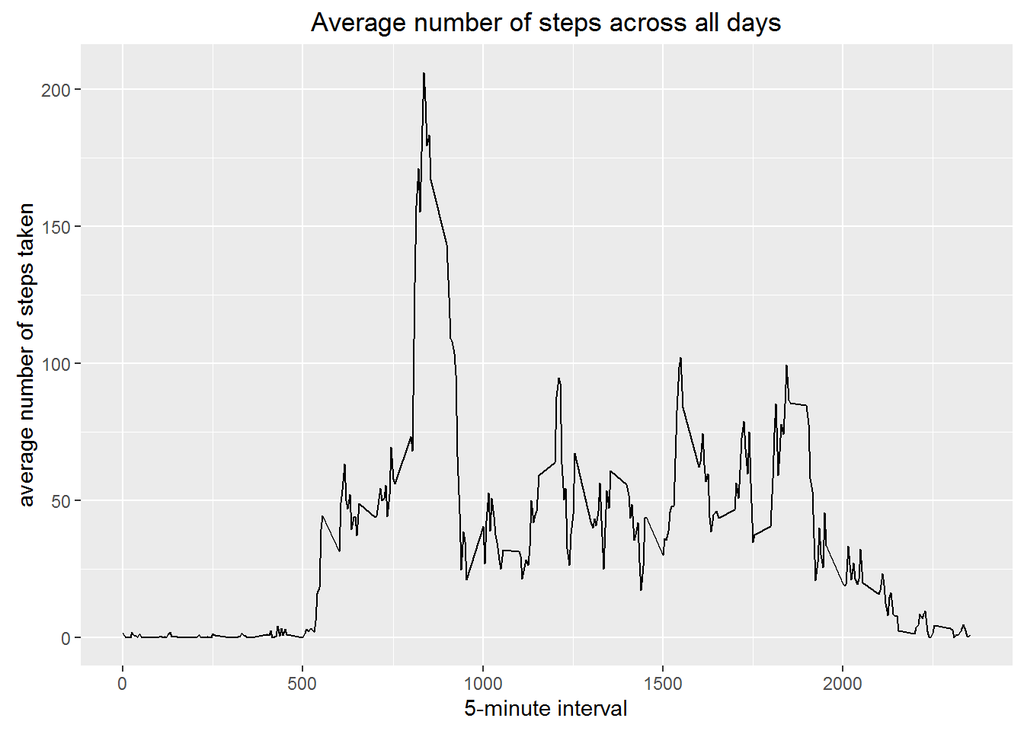

```r
ggplot(data = daily.average, aes(x = interval, y = steps)) +
  geom_line() +
  ggtitle("Average number of steps across all days") +
  xlab("5-minute interval") +
  ylab("average number of steps taken")
```

## Which 5-minute interval, on average across all the days in the dataset, contains the maximum number of steps?

```r
daily.average[which.max(daily.average$steps),]
```

```
##     interval    steps
## 104      835 206.1698
```

```r
# interval    steps
# 104      835 206.1698
```

# total number of missing values in the dataset

```r
missing.values <- length(which(is.na(data$steps)))
#missing.values
#2304 rows have missing values
```

## Devise a strategy for filling in all of the missing values in the dataset. The strategy does not need to be sophisticated.

## For example, you could use the mean/median for that day, or the mean for that 5-minute interval, etc.

### Replace each missing value with the mean value of its 5-minute interval

### Create a new dataset that is equal to the original dataset but with the missing data filled in.

```r
fill.value <- function(steps, interval) {
  filled <- NA
  if (!is.na(steps))
    filled <- c(steps)
  else
    filled <- (daily.average[daily.average$interval==interval, "steps"])
  return(filled)
}
filled.data <- data
filled.data$steps <- mapply(fill.value, filled.data$steps, filled.data$interval)
```

## Histogram of the total number of steps taken each day

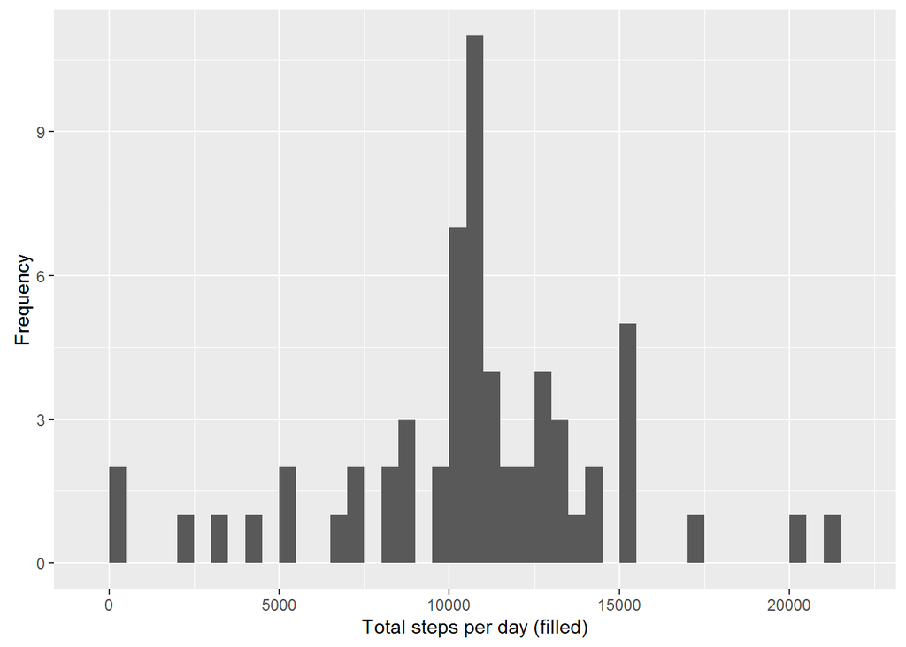

```r
stepsByDay.filled <- tapply(filled.data$steps, filled.data$date, sum)
qplot(stepsByDay.filled, xlab = 'Total steps per day (filled)', ylab = 'Frequency', binwidth = 500)
```

```r
# mean and median total number of steps taken per day
stepsByDayMean.filled <- mean(stepsByDay.filled)
stepsByDayMedian.filled <- median(stepsByDay.filled)
```

[output not shown]

## Are there differences in activity patterns between weekdays and weekends?

### 1. Create a new factor variable in the dataset with two levels - “weekday” and “weekend”

### indicating whether a given date is a weekday or weekend day.

```r
filled.data$datetype <-  ifelse(as.POSIXlt(filled.data$date)$wday %in% c(0,6), 'weekend', 'weekday')
```

### 2. Make a panel plot containing a time series plot (i.e. type = “l”) of the 5-minute interval (x-axis) and

### the average number of steps taken, averaged across all weekday days or weekend days (y-axis). See the README

### file in the GitHub repository to see an example of what this plot should look like using simulated data.

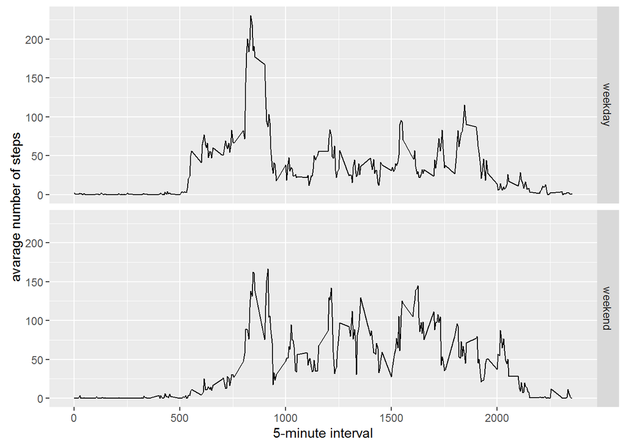

```r
average.filled.data <- aggregate(steps ~ interval + datetype, data = filled.data, mean)
ggplot(average.filled.data, aes(interval, steps)) +
  geom_line() +
  facet_grid(datetype ~ .) +
  xlab("5-minute interval") +
  ylab("avarage number of steps")
```